# Lecture 3: PY 0782 - Advanced Quantitative Research Methods

2018-10-11 | disclaimer

## PY0782: Advanced Quantitative research methods.

Last week: All about visualization.

Today: ANOVA

## Goals (today)

- ANOVA and its variants
- Non-parametric alternatives.

## Assignment

After today you should be able to complete the following sections:

- ANOVA / ANCOVA / MANOVA
- Non-parametric alternatives to these.

## ANOVA

Raise your hand if you have never conducted an ANOVA. Analysis of Variance.

[figure not shown]

## Back to basics: Variance.

A note on notation: \[\sigma^2, s^2, var(X)\]

A measure of **variability**

Can you name other measures?

We can calculate it for a *sample* but usually we want to infer this for a *population*.

Remember \[SD=\sqrt{variance}\]

## Why would you need an ANOVA?

We want to compare differences between two or **more** means.

Why not simply run a bunch of *t*-tests?

Type I error! (a lot of type I errors)

## How does it work?

Imagine a study with three groups –> three means: \(\bar x_1, \bar x_2, \bar x_3\)

We want to find out if those significantly differ.

Grand mean: \(\bar x_g\)

## Formulae (for your reference)

Within- and Between- Sum of Squares (SS)

Mean square within (with 3 samples): \[M_{WithinSS}=\dfrac{\sigma_1^2+\sigma_2^2 + \sigma_3^2}3\]

Mean square between:\[M_{BetweenSS}= \dfrac{\sum_{i=1}^n (\bar x_i - \bar x_g)^2}{N-1}\] with N-1.

Basic gist: if between > within evidence for an effect!

## F-test

\[F= \dfrac{M_{BetweenSS}}{M_{WithinSS}}\]

look up corresponding degrees of freedom.

Compare significance.

## Assumptions.

Dependent variable is interval.

Independent observation (more about this when we discuss multilevel models).

Normally distributed for each category of the Independent variable.

[Homogeneity of variance](http://davidmlane.com/hyperstat/A45619.html)

[figure not shown]

## Time for a new dataset?

Go to https://psychology.okstate.edu/faculty/jgrice/personalitylab/methods.htm#MANOVA

Download the SPSS dataset to your working folder

Open the SPSS dataset.

## Load data.

Three groups (Asians (international), Asian Americans, European Americans), NEO PI-R. Read more [here](https://psychology.okstate.edu/faculty/jgrice/personalitylab/Grice_Iwasaki_AMR.pdf)

```r
setwd("~/Dropbox/Teaching_MRes_Northumbria/Lecture3")
require(haven)
data <- read_spss("Iwasaki_Personality_Data.sav")
```

## Skim

```r
require(skimr)
skim(data)
```

```
## Skim summary statistics
##  n obs: 205
##  n variables: 7
##
## ── Variable type:character ────────────────────────────────────────────────────────────────────────────
##  variable missing complete   n min max empty n_unique
##       GRP       2      203 205   1   1     0        3
##
## ── Variable type:numeric ──────────────────────────────────────────────────────────────────────────────
##  variable missing complete   n   mean     sd p0   p25 p50   p75 p100
##         A       0      205 205 113.75  20.61  0 103   115 127    192
##         C       0      205 205 111.62  20.81  0  98   112 124    192
##         E       0      205 205 116.53  22.09  0 103   117 130    192
##        ID       2      203 205 369.98 256.78  1  51.5 527 577.5  628
##         N       0      205 205  95.91  23.17  0  81    97 110    192
##         O       0      205 205 116.22  20.57  0 104   115 127    192
##      hist
##  ▁▁▁▂▇▆▁▁
##  ▁▁▁▃▇▆▁▁
##  ▁▁▁▂▇▅▂▁
##  ▇▁▁▁▁▁▅▇
##  ▁▁▃▇▇▂▁▁
##  ▁▁▁▂▇▆▁▁
```

## Reduced set.

2 missings. Remove this, find out the codings.

```r
require(dplyr)
# missings are Not a number.
data_no_miss <- filter(data, GRP != "NaN")
print_labels(data_no_miss$GRP)
```

```
##
## Labels:
##  value                label
##      0   European Americans
##      1 Asian Internationals
##      2      Asian Americans
```

## Openness to Experience.

Test whether groups differ in Openness to Experience (O) based on their culture.

[figure not shown]

## Assumption Checks.

Non-independent observations = check!

Interval dependent = check!

Normality –> Plot

Homogeneity of variance.

## Plot

Look back at week 2 to make this a more beautiful plot!

Mostly people would look at the *overall* plot, but ideally one would check plots for each group.

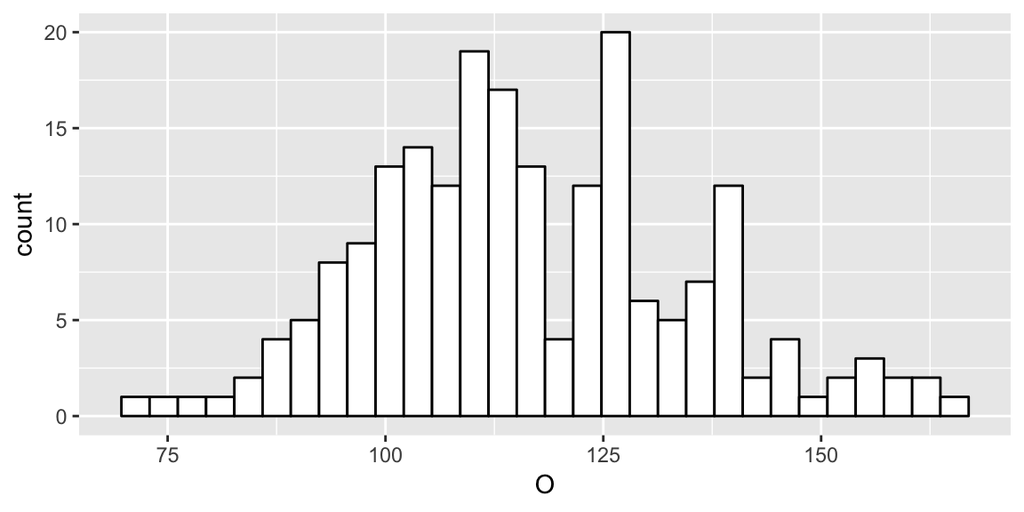

```r
require(ggplot2)
plot_hist <- ggplot(data_no_miss, aes(x = O))
plot_hist <- plot_hist + geom_histogram(colour = "black", fill = "white")
plot_hist
```

## Plot facets.

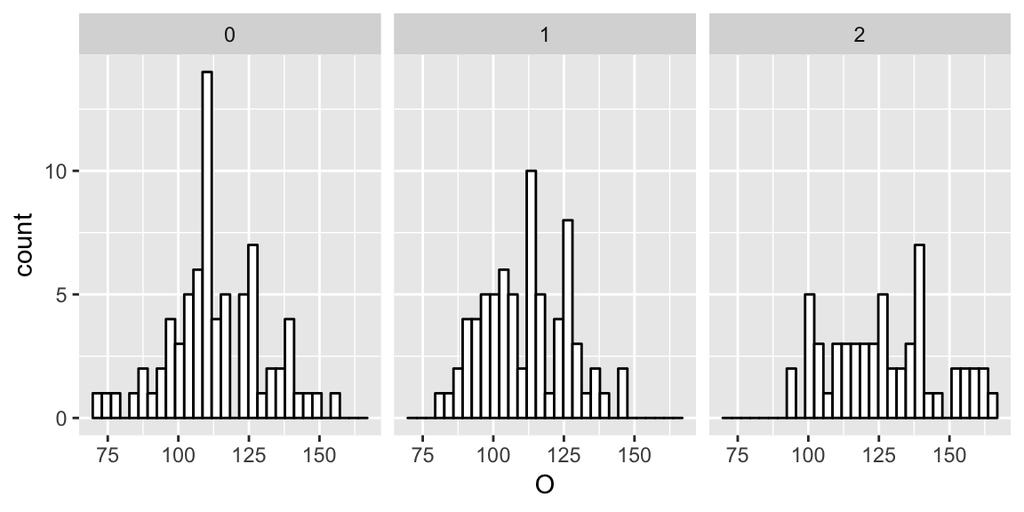

```r
plot_hist_facet <- ggplot(data_no_miss, aes(x = O))
plot_hist_facet <- plot_hist_facet + geom_histogram(colour = "black",
    fill = "white")
plot_hist_facet + facet_wrap(~GRP)
```

## Normality

What do you think?

## Fairly Robust.

Remember central limit theorem!

[figure not shown]

## Other approaches: Shapiro-Wilk

Not significant –> retain null hypothesis, not significantly different from normal distribution.

```r
data_eur <- filter(data_no_miss, GRP == "0")
data_asian_i <- filter(data_no_miss, GRP == "1")
data_asian_a <- filter(data_no_miss, GRP == "2")
# You would do this for all 3!
shapiro.test(data_asian_a$O)
```

```
##
##  Shapiro-Wilk normality test
##
## data:  data_asian_a$O
## W = 0.96901, p-value = 0.1584
```

## Kolmogorov-Smirnov.

Beware K-S test: easily significant!

```r
ks.test(data_asian_a$O, "pnorm")  #pnorm --> normal distribution
```

```
##
##  One-sample Kolmogorov-Smirnov test
##
## data:  data_asian_a$O
## D = 1, p-value < 2.2e-16
## alternative hypothesis: two-sided
```

## Visual checks.

Recommendation check normality visually! (histogram / violin plot / …)

Think back to the 'Datasaurus'.

[figure not shown]

## Variety of other options.

??nortest package. Read the vignette and references.

Anderson-Darling test.

Cramer-von Mises test.

Lilliefors test (K-S) (correction of K-S).

Shapiro-Francia test.

Jarque Bera test (+ adjusted).

## Homogeneity of variance.

Bartlett's test - assumes normality.

If significant could also point to deviation in normality as opposed to violation of the assumption of homogeneity of variance.

```r
bartlett.test(O ~ GRP, data = data_no_miss)
```

```
##
##  Bartlett test of homogeneity of variances
##
## data:  O by GRP
## Bartlett's K-squared = 3.1821, df = 2, p-value = 0.2037
```

## Levene's test.

[Levene's test](http://www.itl.nist.gov/div898/handbook/eda/section3/eda35a.htm) does not assume normality.

```r
require(car)  # package which does test
require(dplyr)
# need to make it a factor!
data_no_miss$GRP_fact <- as_factor(data_no_miss$GRP)
leveneTest(O ~ GRP_fact, data = data_no_miss)
```

```
## Levene's Test for Homogeneity of Variance (center = median)
##        Df F value Pr(>F)
## group   2  1.7076 0.1839
##       200
```

## Outcome of assumption checks.

Assumptions upheld here!

Sample write up: Visual inspection suggested that the distribution of the dependent variable is close to normal. A Levene's test suggests that the assumption of homogeneity of variances is not violated, *F*(2,200) = 1.71, *p*= .18)

We can move on to ANOVA!

[figure not shown]

## Kurtosis/Skewness.

As an aside: you could mention, the platykurtosis in the Asian American group.

(In your assignment I would count both correct in this case).

[figure not shown]

## Try it yourself.

Test the assumptions for an ANOVA with Extraversion (E) and group as independent variable.

[figure not shown]

## ANOVA.

[Many ways to do an ANOVA.](http://talklab.psy.gla.ac.uk/r_training/anova/index.html#orgheadline5)

Why this matters will become clearer when we discuss.

## aov()

Analysis of variance.

```r
Anova1 <- aov(O ~ GRP_fact, data = data_no_miss)
summary(Anova1)
```

```
##              Df Sum Sq Mean Sq F value   Pr(>F)
## GRP_fact      2   8774    4387   15.05 8.13e-07 ***
## Residuals   200  58284     291
## ---
## Signif. codes:  0 '***' 0.001 '**' 0.01 '*' 0.05 '.' 0.1 ' ' 1
```

## lm(): Linear model.

```r
Anova2 <- lm(O ~ GRP_fact, data = data_no_miss)
summary(Anova2)
```

```
##
## Call:
## lm(formula = O ~ GRP_fact, data = data_no_miss)
##
## Residuals:
##     Min      1Q  Median      3Q     Max
## -41.400 -11.982  -0.982  11.828  41.600
##
## Coefficients:
##                              Estimate Std. Error t value Pr(>|t|)
## (Intercept)                   113.400      1.971  57.529  < 2e-16 ***
## GRP_factAsian Internationals   -2.039      2.817  -0.724     0.47
## GRP_factAsian Americans        13.582      3.015   4.505 1.13e-05 ***
## ---
## Signif. codes:  0 '***' 0.001 '**' 0.01 '*' 0.05 '.' 0.1 ' ' 1
##
## Residual standard error: 17.07 on 200 degrees of freedom
## Multiple R-squared:  0.1308, Adjusted R-squared:  0.1222
## F-statistic: 15.05 on 2 and 200 DF,  p-value: 8.126e-07
```

## F-test.

summary prints parameter tests but should you be after the *F*-test.

```r
anova(Anova2)
```

```
## Analysis of Variance Table
##
## Response: O
##            Df Sum Sq Mean Sq F value    Pr(>F)
## GRP_fact    2   8774  4387.0  15.054 8.126e-07 ***
## Residuals 200  58284   291.4
## ---
## Signif. codes:  0 '***' 0.001 '**' 0.01 '*' 0.05 '.' 0.1 ' ' 1
```

## Drop1.

For your reference. drop1 can also get you some relevant key info.

Don't worry about [AIC](https://en.wikipedia.org/wiki/Akaike_information_criterion) for now. It is a model fit statistic (lower = better). More about this when we discuss multilevel models.

```r
drop1(Anova2)  # some additional info. ??drop1
```

```
## Single term deletions
##
## Model:
## O ~ GRP_fact
##          Df Sum of Sq   RSS    AIC
## <none>                58284 1155.0
## GRP_fact  2      8774 67058 1179.4
```

## ez Package

Best bet for replicating SPSS results!

```r
require(ez)
Ez_ANOVA1 <- ezANOVA(data_no_miss, dv = O, wid = ID, between = GRP_fact,
    detailed = TRUE)
```

```r
Ez_ANOVA1
```

```
## $ANOVA
##     Effect DFn DFd      SSn      SSd        F            p p<.05       ges
## 1 GRP_fact   2 200 8773.973 58283.59 15.05393 8.125554e-07     * 0.1308424
##
## $`Levene's Test for Homogeneity of Variance`
##   DFn DFd      SSn      SSd        F       p p<.05
## 1   2 200 356.9336 20903.13 1.707561 0.18394
```

## ges?

Effect size measure!

ges= Generalized Eta-Squared. \(\eta^2_g\) . There is also *partial* \(\eta^2\). Read more [here](https://egret.psychol.cam.ac.uk/statistics/local_copies_of_sources_Cardinal_and_Aitken_ANOVA/glm_effectsize.htm).

How to do Greek symbols and mathematical functions? [here](http://csrgxtu.github.io/2015/03/20/Writing-Mathematic-Fomulars-in-Markdown/) or check the .rmd for this lecture.

## Omega squared and partial omega squared.

If you are up for a challenge. You can figure out how to calculate this effect size measure on your own!.

[figure not shown]

## write up.

A one-way ANOVA showed a significant effect of cultural group on openness to experience *F*(2, 200) = 15.05, *p* < .0001, \(\eta^2_g\) = .13.

## Store results

```r
require(apaTables)
apa.aov.table(Anova1, filename = "APA_Anova_Table.doc", table.number = 1)
```

```
##
##
## Table 1
##
## ANOVA results using O as the dependent variable
##
##
##    Predictor        SS  df        MS       F    p partial_eta2
##  (Intercept) 964467.00   1 964467.00 3309.57 .000
##     GRP_fact   8773.97   2   4386.98   15.05 .000          .13
##        Error  58283.59 200    291.42
##  CI_90_partial_eta2
##
##          [.06, .20]
##
##
## Note: Values in square brackets indicate the bounds of the 90% confidence interval for partial eta-squared
```

## Post-hoc tests.

Where does the difference lie?

[figure not shown]

## Post-hoc tests.

```r
resultTukey <- TukeyHSD(Anova1)
resultTukey
```

```
##   Tukey multiple comparisons of means
##     95% family-wise confidence level
##
## Fit: aov(formula = O ~ GRP_fact, data = data_no_miss)
##
## $GRP_fact
##                                              diff       lwr       upr
## Asian Internationals-European Americans -2.038889 -8.689634  4.611856
## Asian Americans-European Americans      13.582143  6.463135 20.701151
## Asian Americans-Asian Internationals    15.621032  8.438902 22.803161
##                                             p adj
## Asian Internationals-European Americans 0.7496332
## Asian Americans-European Americans      0.0000335
## Asian Americans-Asian Internationals    0.0000020
```

## Post-hoc tests: corrections.

Have you heard of post-hoc corrections? Why do they exist?

Read more [here](https://stats.idre.ucla.edu/r/faq/how-can-i-do-post-hoc-pairwise-comparisons-in-r/) and use them sensibly.

Why Bonferroni should be abandoned (in [medicine](https://www.ncbi.nlm.nih.gov/pmc/articles/PMC1112991/) and [ecology](https://academic.oup.com/beheco/article/15/6/1044/206216/A-farewell-to-Bonferroni-the-problems-of-low)).

[figure not shown]

## Make a report. Stargazer.

You can make a prettier layout. By changing the variable names, etc. You can also change the labels it prints.

Totally check out stargazer!

```r
require(broom)
require(stargazer)
# Broom turns our result into a dataframe!  We can then
# 'tidy' it and make a report!
tidy_resultTukey <- tidy(resultTukey)
stargazer(tidy_resultTukey, summary = F, type = "html", out = "Tukey.html")
```

## apaTables

Alternative. This will also have Cohen's d effect size values.

```r
require(apaTables)
apa.d.table(iv = GRP_fact, dv = O, data = data_no_miss,
    filename = "Table_1_APA_tukey.doc", show.conf.interval = T,
    landscape = T, table.number = 1)
```

```
##
##
## Table 1
##
## Means, standard deviations, and d-values with confidence intervals
##
##
##   Variable                M      SD    1             2
##   1. European Americans   113.40 17.12
##
##   2. Asian Internationals 111.36 15.24 0.13
##                                        [-0.20, 0.45]
##
##   3. Asian Americans      126.98 19.11 0.75          0.92
##                                        [0.40, 1.11]  [0.55, 1.28]
##
##
## Note. M indicates mean. SD indicates standard deviation. d-values are estimates calculated using formulas 4.18 and 4.19
## from Borenstein, Hedges, Higgins, & Rothstein (2009). d-values not calculated if unequal variances prevented pooling.
## Values in square brackets indicate the 95% confidence interval for each d-value.
## The confidence interval is a plausible range of population d-values
## that could have caused the sample d-value (Cumming, 2014).
##
```

## Try it yourself.

- Run an ANOVA with 'E' extraversion as the dependent, and group as the independent.
- Conduct the post-hoc tests and export those as either .html or .docx

## What if we were unlucky?

How would you have proceeded, if the assumptions were violated?

[figure not shown]

## Non-parametric tests.

They do not assume a normal distribution but can be less powerful.

Many options exist. You can read and find others (see references).

[figure not shown]

## WRS2 package

lincoln() for the posthoc tests.

```r
# WRS.
require(WRS2)
t1way(O ~ GRP_fact, data = data_no_miss)
```

```
## Call:
## t1way(formula = O ~ GRP_fact, data = data_no_miss)
##
## Test statistic: F = 11.067
## Degrees of freedom 1: 2
## Degrees of freedom 2: 74.67
## p-value: 6e-05
##
## Explanatory measure of effect size: 0.44
```

## t1waybt (WRS2)

The t1waybt function computes a one-way ANOVA for the [*trimmed means*](http://davidmlane.com/hyperstat/A11971.html).

```r
# Specify Between.
t1waybt(O ~ GRP_fact, data = data_no_miss, nboot = 10000)
```

```
## Call:
## t1waybt(formula = O ~ GRP_fact, data = data_no_miss, nboot = 10000)
##
## Effective number of bootstrap samples was 10000.
##
## Test statistic: 11.067
## p-value: 2e-04
## Variance explained 0.192
## Effect size 0.439
```

## med1way (WRS2)

Computes a one-way ANOVA for the medians. Homoscedasticity assumption not required. Avoid too many ties.

```r
# WRS, ANOVA for Medians. (note iter=)
med1way(O ~ GRP_fact, data = data_no_miss, iter = 10000)
```

```
## Call:
## med1way(formula = O ~ GRP_fact, data = data_no_miss, iter = 10000)
##
## Test statistic F: 6.6673
## Critical value: 3.2621
## p-value: 0.0036
```

```r
# analysis of Medians leads to same conclusion.
```

Read through WRS2 manual or Wilcox (2012) to find out more.

## Permutation tests.

Permutation tests use random shuffles of the data to get the correct distribution of a test statistic under a null hypothesis. (No power issue by the way)

Shuffles are not the same as bootstraps. Some assumptions do still apply (e.g., non-independence of observations).

Read more [here](http://thomasleeper.com/Rcourse/Tutorials/permutationtests.html) and [here](http://rcompanion.org/handbook/K_01.html)

```r
require(coin)
independence_test(O ~ GRP_fact, data = data_no_miss)
```

```
##
##  Asymptotic General Independence Test
##
## data:  O by
##   GRP_fact (European Americans, Asian Internationals, Asian Americans)
## maxT = 5.0961, p-value = 8.742e-07
## alternative hypothesis: two.sided
```

## Sample write up.

A permutation test via the 'coin' package showed that there are significant differences between the three groups in Openness to Experience (maxT= 5.10, *p*< .0001).

(Note post-hoc tests are currently unavailable via 'coin' but you can get them via 'rcompanion', more [here](https://rcompanion.org/rcompanion/d_06a.html))

## ANCOVA

The difference is the *C*. Covariate.

Often we want to control for a potential confound, so suppose that you are testing a new weight loss drug. You could analyse the participant's weight at the end of the trial while partialling out their start weight. This would be an ANCOVA scenario (but [beware](http://files.eric.ed.gov/fulltext/ED312298.pdf)).

## Important: order effects.

The order in which you put in things matters!!

```r
# Type I errors
lm_ancova <- lm(O ~ E + GRP_fact, data = data_no_miss)
anova(lm_ancova)
```

```
## Analysis of Variance Table
##
## Response: O
##            Df Sum Sq Mean Sq F value    Pr(>F)
## E           1   8349  8348.9  34.339 1.894e-08 ***
## GRP_fact    2  10325  5162.7  21.234 4.379e-09 ***
## Residuals 199  48383   243.1
## ---
## Signif. codes:  0 '***' 0.001 '**' 0.01 '*' 0.05 '.' 0.1 ' ' 1
```

## Compare to previous slide!

```r
# note that the order matters for the F-tests.
lm_ancova2 <- lm(O ~ GRP_fact + E, data = data_no_miss)
anova(lm_ancova2)
```

```
## Analysis of Variance Table
##
## Response: O
##            Df Sum Sq Mean Sq F value    Pr(>F)
## GRP_fact    2   8774  4387.0  18.044 6.289e-08 ***
## E           1   9900  9900.3  40.720 1.209e-09 ***
## Residuals 199  48383   243.1
## ---
## Signif. codes:  0 '***' 0.001 '**' 0.01 '*' 0.05 '.' 0.1 ' ' 1
```

## More about Types of errors later.

Type I,II,III errors.

For now, you should be aware that type of errors matters (I,II,III). read more [here](http://www.utstat.toronto.edu/reid/sta442f/2009/typeSS.pdf) and [here](https://bookdown.org/ndphillips/YaRrr/anova.html#type-i-type-ii-and-type-iii-anovas)

SPSS uses type III. So let's aim to emulate (even though that might not always be [optimal](http://www.dwoll.de/r/ssTypes.php))

## Order invariant: SPSS uses Type III.

```r
# Type III errors
require(car)
require(compute.es)
Ancova <- lm(O ~ GRP_fact + E, contrasts = list(GRP_fact = contr.sum),
    data = data_no_miss)
Anova(Ancova, type = "III")
```

```
## Anova Table (Type III tests)
##
## Response: O
##             Sum Sq  Df F value    Pr(>F)
## (Intercept)  25976   1 106.838 < 2.2e-16 ***
## GRP_fact     10325   2  21.234 4.379e-09 ***
## E             9900   1  40.720 1.209e-09 ***
## Residuals    48383 199
## ---
## Signif. codes:  0 '***' 0.001 '**' 0.01 '*' 0.05 '.' 0.1 ' ' 1
```

## post-hoc tests.

```r
require(multcomp)
posth = glht(Ancova, linfct = mcp(GRP_fact = "Tukey"))
```

## summary(posth)

```r
summary(posth)  ##shows the output in a nice format
```

```
##
##   Simultaneous Tests for General Linear Hypotheses
##
## Multiple Comparisons of Means: Tukey Contrasts
##
##
## Fit: lm(formula = O ~ GRP_fact + E, data = data_no_miss, contrasts = list(GRP_fact = contr.sum))
##
## Linear Hypotheses:
##                                                Estimate Std. Error t value
## Asian Internationals - European Americans == 0    4.837      2.789   1.734
## Asian Americans - European Americans == 0        17.870      2.835   6.304
## Asian Americans - Asian Internationals == 0      13.033      2.808   4.642
##                                                Pr(>|t|)
## Asian Internationals - European Americans == 0    0.195
## Asian Americans - European Americans == 0        <1e-04 ***
## Asian Americans - Asian Internationals == 0      <1e-04 ***
## ---
## Signif. codes:  0 '***' 0.001 '**' 0.01 '*' 0.05 '.' 0.1 ' ' 1
## (Adjusted p values reported -- single-step method)
```

## Sample write up.

A one-way ANCOVA was conducted to compare Openness across groups whilst controlling for Extraversion. There was a significant effect of cultural group, *F*(2,199)=21.23, *p*<.0001. In addition, the effect of the covariate, Extraversion, was significant, *F*(1,199)=40.72, *p*<.0001.

You would then describe the post-hoc differences and also explore how extraversion is associated with (e.g., correlation, plot.)

## Non-parametric alternative.

Look at the 'lmPerm' package and [this](https://statmethods.wordpress.com/2012/05/21/permutation-tests-in-r/).

## MANOVA

All the previous assumptions + (+ multicollinearity (not an assumption but a problem)

Multivariate normality

Homogeneity of *co*-variances.

## Multivariate Normality

[Multivariate Shapiro test.](https://en.wikipedia.org/wiki/Shapiro%E2%80%93Wilk_test) (The Univariate's test bigger brother…).

Sensitive to sample size, if large small deviations will lead to significance.

```r
require(RVAideMemoire)
multivariatenorm <- dplyr::select(data_no_miss, -GRP_fact, -GRP,
    -ID)
mshapiro.test(multivariatenorm)
```

```
##
##  Multivariate Shapiro-Wilk normality test
##
## data:  (N,E,O,A,C)
## W = 0.98577, p-value = 0.03887
```

## Alternative methods.

A whole host of alternatives. More [here](http://dwoll.de/rexrepos/posts/normality.html).

```r
require(MVN)  # Alternative method, one example
mvn(multivariatenorm)
```

```
## $multivariateNormality
##              Test        Statistic            p value Result
## 1 Mardia Skewness 57.0115702615851 0.0107887129793524     NO
## 2 Mardia Kurtosis  1.9394290567207 0.0524491152485054    YES
## 3             MVN             <NA>               <NA>     NO
##
## $univariateNormality
##           Test  Variable Statistic   p value Normality
## 1 Shapiro-Wilk     N        0.9942    0.6210    YES
## 2 Shapiro-Wilk     E        0.9897    0.1552    YES
## 3 Shapiro-Wilk     O        0.9893    0.1360    YES
## 4 Shapiro-Wilk     A        0.9915    0.2815    YES
## 5 Shapiro-Wilk     C        0.9889    0.1158    YES
##
## $Descriptives
##     n     Mean  Std.Dev Median Min Max  25th  75th       Skew   Kurtosis
## N 203  95.9064 21.23737     97  36 160  81.0 109.5 -0.1442702 -0.1102764
## E 203 116.7291 19.93406    117  50 175 103.0 129.5 -0.1039661  0.6504353
## O 203 116.4236 18.21999    115  72 166 104.0 127.0  0.3079877 -0.1699643
## A 203 113.9261 18.29136    115  58 161 103.0 127.0 -0.2962256  0.1136037
## C 203 111.7734 18.53971    112  57 171  98.5 124.0  0.1476949  0.4428221
```

## Conclusion: Multivariate normality

Violated (but could be way worse, trust me … )

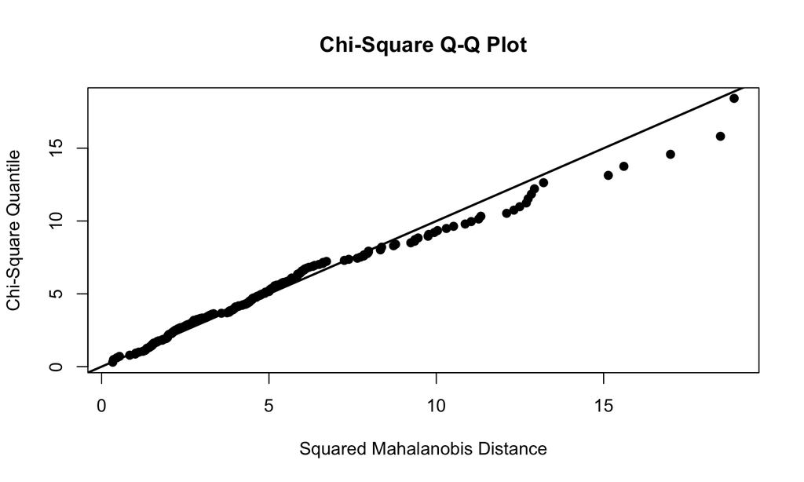

```
## $multivariateNormality
##              Test        Statistic            p value Result
## 1 Mardia Skewness 57.0115702615851 0.0107887129793524     NO
## 2 Mardia Kurtosis  1.9394290567207 0.0524491152485054    YES
## 3             MVN             <NA>               <NA>     NO
##
## $univariateNormality
##           Test  Variable Statistic   p value Normality
## 1 Shapiro-Wilk     N        0.9942    0.6210    YES
## 2 Shapiro-Wilk     E        0.9897    0.1552    YES
## 3 Shapiro-Wilk     O        0.9893    0.1360    YES
## 4 Shapiro-Wilk     A        0.9915    0.2815    YES
## 5 Shapiro-Wilk     C        0.9889    0.1158    YES
##
## $Descriptives
##     n     Mean  Std.Dev Median Min Max  25th  75th       Skew   Kurtosis
## N 203  95.9064 21.23737     97  36 160  81.0 109.5 -0.1442702 -0.1102764
## E 203 116.7291 19.93406    117  50 175 103.0 129.5 -0.1039661  0.6504353
## O 203 116.4236 18.21999    115  72 166 104.0 127.0  0.3079877 -0.1699643
## A 203 113.9261 18.29136    115  58 161 103.0 127.0 -0.2962256  0.1136037
## C 203 111.7734 18.53971    112  57 171  98.5 124.0  0.1476949  0.4428221
```

```r
mvn(multivariatenorm, multivariatePlot = "qq")
```

## Solutions.

Solution: Check for outliers, run analyses again. Report both!

Transformations. [Box-Cox transform](https://stat.ethz.ch/R-manual/R-devel/library/MASS/html/boxcox.html).

Central limit theorem to the rescue again! (also note Hotelling's T^2 robust)

[figure not shown]

## Homogeneity of variance.

As with the univariate case. So, you would run a series of tests such as Levene's Test and examine those.

Not done here but you can run these on your own.

## Homogeneity of covariances: Box's M test.

Approach with care.

Very easily significant. Therefore, usually *p*=.001 as threshold. More [here](https://en.wikiversity.org/wiki/Box%27s_M).

```r
require(heplots)  #alternative is 'biotools' package.
boxM(multivariatenorm, data_no_miss$GRP)
```

```
##
##  Box's M-test for Homogeneity of Covariance Matrices
##
## data:  multivariatenorm
## Chi-Sq (approx.) = 40.668, df = 30, p-value = 0.09256
```

## MANOVA

```r
Manovamodel <- manova(cbind(N, E, A, O, C) ~ GRP_fact, data = data_no_miss)
summary(Manovamodel)
```

```
##            Df  Pillai approx F num Df den Df    Pr(>F)
## GRP_fact    2 0.41862    10.43     10    394 1.106e-15 ***
## Residuals 200
## ---
## Signif. codes:  0 '***' 0.001 '**' 0.01 '*' 0.05 '.' 0.1 ' ' 1
```

## MANOVA

Other measures exist but Pillai's Trace is typically most common. You can find out more about them [here](https://onlinecourses.science.psu.edu/stat505/node/163). Also about the **math** (also see references).

[figure not shown]

## Report.

Pillai's Trace most commonly reported.

Sample report: A MANOVA was conducted with five dependent variables (Neuroticism, Extraversion, Conscientousness, Agreeableness, and Openness to Experience) and cultural group as the between-subject factor. A statistically significant effect was found (Pillai's Trace= .42, *F*(10,394)=10.43, *p*<.0001).

You would then report follow-up tests! (e.g., Univariate ANOVA's)

In conclusion the personality profiles differ between these 3 groups.

## Follow up tests

Univariate ANOVA's / plot your data / [Discriminant analysis](http://geog.uoregon.edu/bartlein/courses/geog495/lec17.html).

## Exercise.

Using last week's Salaries dataset, test the assumptions for an ANOVA with monthly salary as dependent variable and academic rank as independent variable.

Conduct an ANOVA with the appropriate post-hoc tests. What do you conclude?

Conduct an alternative non-parametric test to the ANOVA. What do you conclude.

Conduct an ANCOVA with gender as factor, and years since Ph.D. as covariate. What do you conclude?

## Exercise continued.

Load the iris dataset, it is part of the [datasets package](https://rstudio-pubs-static.s3.amazonaws.com/204918_d5ccf842cbc540e78b3d6d3287e6ad38.html).

It is a famous dataset with measurements of 3 species of iris flowers.

Test the assumptions for a MANOVA with Species as the between-subject factor and petal length and sepal length as dependent variables.

Run the MANOVA. What do you conclude? Write up the result as you would do for a paper?

BONUS: Plot one of the results from your analyses on the salaries database.

BONUS: Conduct a follow up analysis or plot for the MANOVA.

## References (and further reading.)

- Crawley, M. J. (2013). *The R book: Second edition.* New York, NY: John Wiley & Sons.
- Kassambara, A. (2017) STHDA: *[One way ANOVA in R](http://www.sthda.com/english/wiki/one-way-anova-test-in-r)*
- Kassambara, A. (2017) STHDA: *[Statistical tests and assumptions](http://www.sthda.com/english/wiki/statistical-tests-and-assumptions)*
- Mangiafico, S. (2017) [rcompanion](http://rcompanion.org/handbook/)
- Siegel, S. & Castellan, N.J. Jr. (1988). *Nonparametric statistics for the behavioral sciences. 2nd Edn.* McGraw-Hill, New York.
- Wickham, H., & Grolemund, G. (2017). *[R for data science](http://r4ds.had.co.nz/)*. Sebastopol, CA: O’Reilly.
- Wilcox, R. (2012). Introduction to Robust Estimation and Hypothesis Testing (3rd ed.). New York, NY: Elsevier.